# College Survey 2014 summary

weiran

June 21, 2016

Data cleannig

```r
# read data
df.person<- read.csv("1_PSRC_College_PersonDataset_2015-1-23_V1-3.csv")
df.trip<- read.csv("2_PSRC_College_TripDataset_2015-1-23_v2-1_LINKED.csv")


cols <- c("college")
df.trip[,cols] <- data.frame(apply(df.trip[cols], 2, as.factor))
levels(df.trip$college) <- c("Bellevue.C","Everett.C", "Green River.C", "Seattle.C", "U.W")

cols1 <- c("college")
df.person[,cols1] <- data.frame(apply(df.person[cols1], 2, as.factor))
levels(df.person$college) <- c("Bellevue.C","Everett.C", "Green River.C", "Seattle.C", "U.W")

df.live <- df.person %>%
  select(personID=personid,live,h_district_name,h_districtnum,home_cnty)

df <- df.trip %>%
  mutate(mode=as.factor(mode),
         vehicle=as.factor(vehicle)) %>%
  mutate(traveldate = dmy(as.character(traveldate))) %>%
  mutate(d_purpose = as.factor(d_purpose),
         o_purpose = as.factor(o_purpose)) %>%
  mutate(trip_commute = ifelse((o_purpose==1 & d_purpose==2)|
                                 (o_purpose==2 & d_purpose ==1),
                               1,0)) %>%
  left_join(df.live,by='personID') %>%    #join person dataset variable
  mutate(add_commute=ifelse(live==2,'off campus','on campus')) %>%
  mutate(trip_commute=as.factor(trip_commute),
         add_commute=as.factor(add_commute)) %>%
  mutate(home_cnty = as.factor(home_cnty))



levels(df$home_cnty) <- c('King','Kitsap','Pierce','Snohomish','Other WA cnty','Outside WA')
```

## Data describe

this describe the sample size of the data among college and campus\

campus code 1 Seattle campus 2 Bothell campus 3 Tacoma campus 4 North Seattle College 5 Seattle Central College 6 South Seattle College (Main Campus) 7 Main campus 8 Enumclaw campus 9 Kent campus 10 Downtown Auburn Center 11 Main campus 12 North campus 13 Online only - I never go to campus 14 South Seattle College (Georgetown Campus) 15 Seattle Vocational Institute

```r
table(df.trip$college)
```

```
##
##    Bellevue.C     Everett.C Green River.C     Seattle.C           U.W
##           155          1317          1141          4945         11720
```

```r
table(df.person$college)
```

```
##
##    Bellevue.C     Everett.C Green River.C     Seattle.C           U.W
##            36           311           268          1254          2542
```

```r
table(df.person$campus)
```

```
##
##    1    2    3    4    5    6    7    8    9   10   11   12   14   15
## 2537    2    3  457  540  218  254    1    7    6   35    1   17   22
```

## 1 Mode choice

mode code: 1 Drove alone 3 Drove/rode with people not in household 4 Motorcycle/moped/scooter 5 Vanpool 6 Bicycle 7 Walk, jog, or wheelchair 8 Bus (public transit) 9 Train (rail and monorail) 10 Ferry or water taxi 11 Streetcar 13 Taxi or other hired car service (e.g. Lyft, Uber) 14 Paratransit 16 Airplane or helicopter 15 Private bus or shuttle 17 Other (e.g. skateboard, kayak, motor home, etc.)

```r
rowPerc(xtabs(~df$mode))
```

```
##
## df$mode     1     3    4    5    6     7     8    9   10   11   13   14
##         23.76 13.31 0.41 0.11 3.75 40.18 17.23 0.36 0.24 0.02 0.13 0.03
##
## df$mode   15   16   17 Total
##         0.35 0.06 0.06   100
```

```r
rowPerc(xtabs(~df[df$trip_commute==1,]$mode)) #commute trip modeshare
```

```
##
## df[df$trip_commute == 1, ]$mode     1    3    4    5    6     7    8    9
##                                 16.27 5.85 0.36 0.21 5.52 34.73 35.5 0.82
##
## df[df$trip_commute == 1, ]$mode   10   11   13   14   15 16   17 Total
##                                 0.41 0.03 0.03 0.03 0.21  0 0.05   100
```

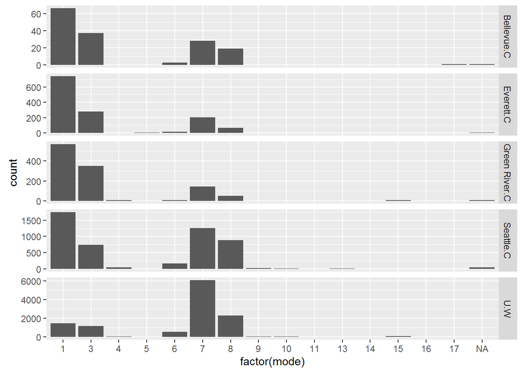

```r
ggplot(df, aes(x=factor(mode)))+ geom_bar()+
  facet_grid(college~.,scale="free")
```

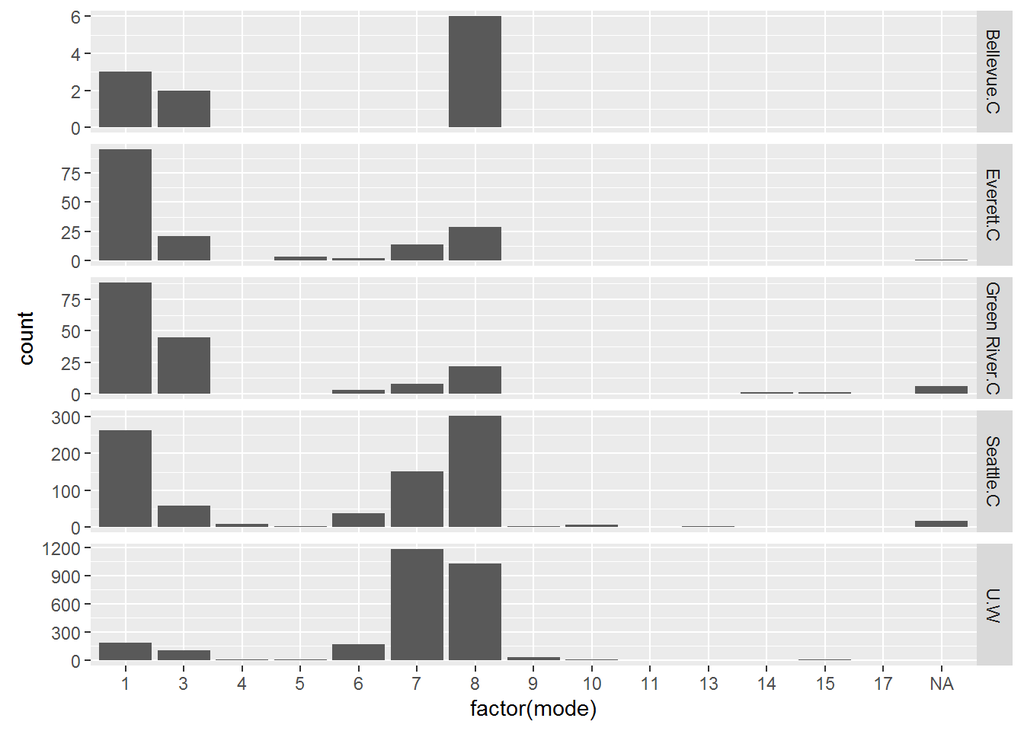

```r
#commute trip modeshare
ggplot(df[df$trip_commute==1,], aes(x=factor(mode)))+ geom_bar()+
  facet_grid(college~.,scale="free")
```

## Trips per day, total and by purpose

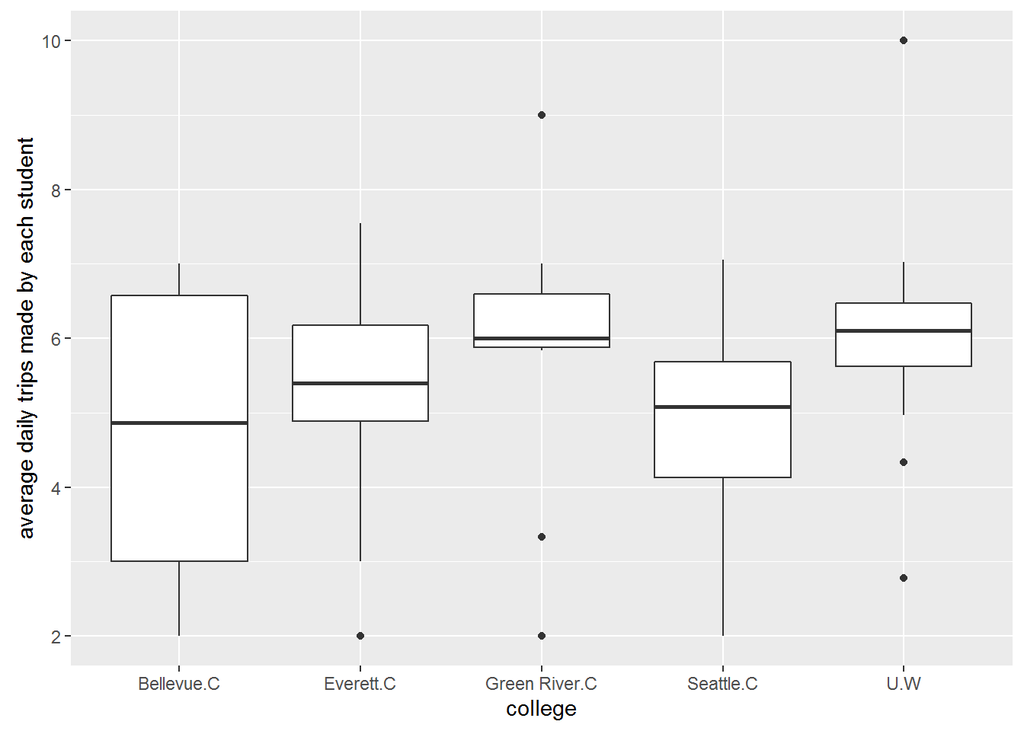

```r
# trips stat summary
df.tripstat<- df.trip %>%
  mutate(traveldate=dmy(as.character(traveldate))) %>%
  distinct()%>%
  group_by(college,traveldate) %>%
  summarise(totaltrip.coldate = mean(total_trip))

# box plot for daily trips made by college. Senseless to summarize total trips,
#since for each school different number of students are sampled
ggplot(df.tripstat,aes(college,totaltrip.coldate)) + geom_boxplot() + ylab('average daily trips made by each student')
```

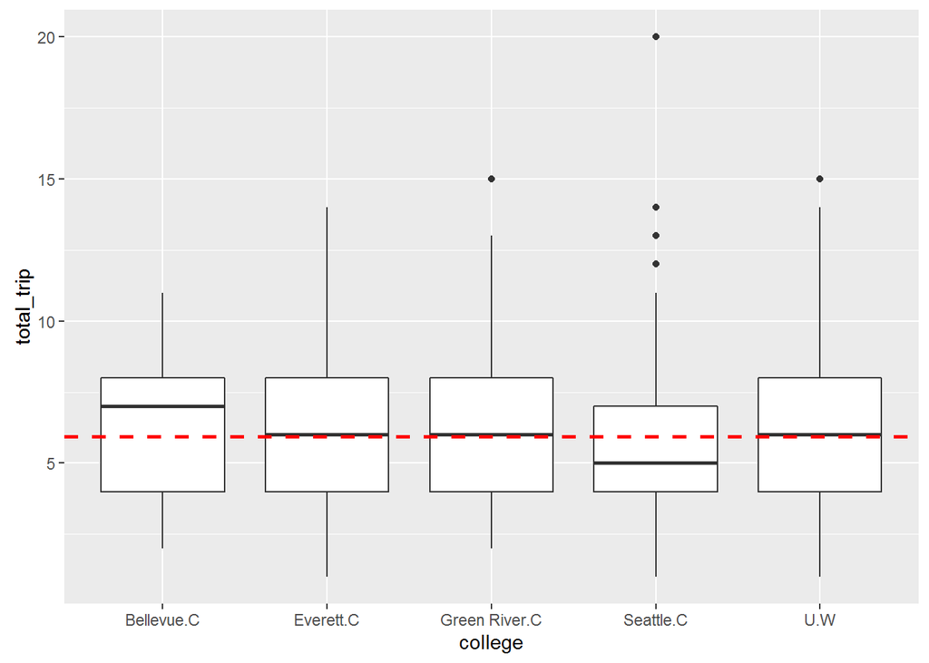

```r
# # box plot for each person each day
ggplot(df.trip,aes(x=college,y=total_trip))+geom_boxplot()+
  geom_hline(aes(yintercept=mean(total_trip, na.rm=T)),
             color="red", linetype="dashed", size=1)
```

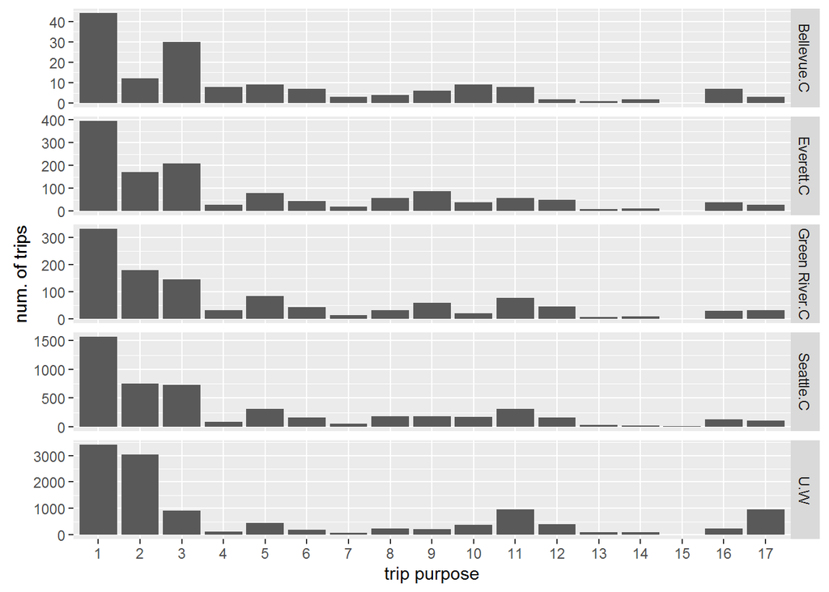

```r
#by purpose
# table(df.trip$d_purpose)
# df.trip$d_purpose <- as.factor(df.trip$d_purpose)

df.trippurpose <- df%>%
  group_by(college,d_purpose) %>%
  summarise(numtrips=n())

ggplot(df.trippurpose,aes(d_purpose,numtrips)) + geom_bar(stat='identity') +
  facet_grid(college~.,scale="free") + xlab('trip purpose') + ylab('num. of trips')
```

## 3. trip length summary

purpose code

1 Go home/to dorm 2 Go to school (e.g. go to class, go to tutoring) 3 Go to work/job 4 Go to other work-related place (e.g. meeting, second job, delivery) 5 Go grocery shopping 6 Go to other shopping (e.g. mall, pet store) 7 Go to medical appointment (e.g. doctor, dentist) 8 Conduct personal business (e.g. bank, post office) 9 Drop off/pick up someone (e.g. drop off friend at bus stop) 10 Go exercise (e.g. gym, walk, jog, bike ride) 11 Go to restaurant to eat/get take-out 12 Attend social event (e.g. visit with friends, family, co-workers) 13 Attend recreational event (e.g. movies, sporting event) 14 Go to religious/community/volunteer activity 15 Transfer to another mode of transportation (e.g. change from ferry to bus) 16 Other 17 Go to school-related activity

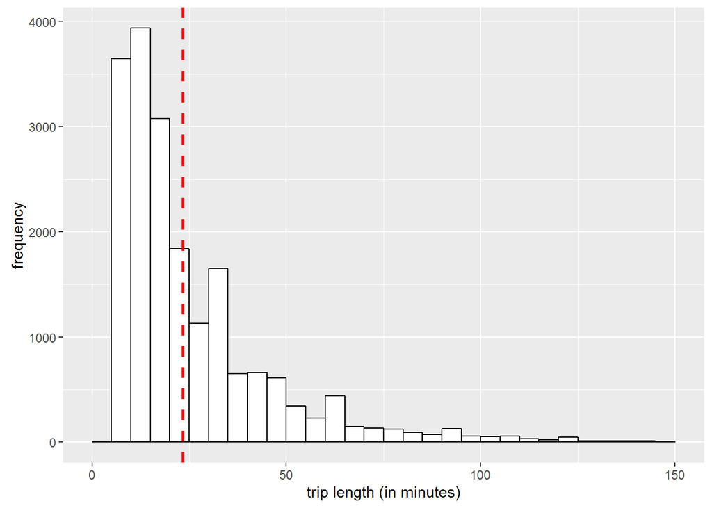

```r
# Trip length/distance frequency and overall
ggplot(df,aes(trip_dur_reported)) +geom_histogram(colour="black", fill="white") +
  geom_vline(aes(xintercept=mean(trip_dur_reported, na.rm=T)),
             color="red", linetype="dashed", size=1)+
  # facet_grid(college~.,scales='free_y') +
  xlim(0,150) + xlab('trip length (in minutes)') + ylab('frequency')
```

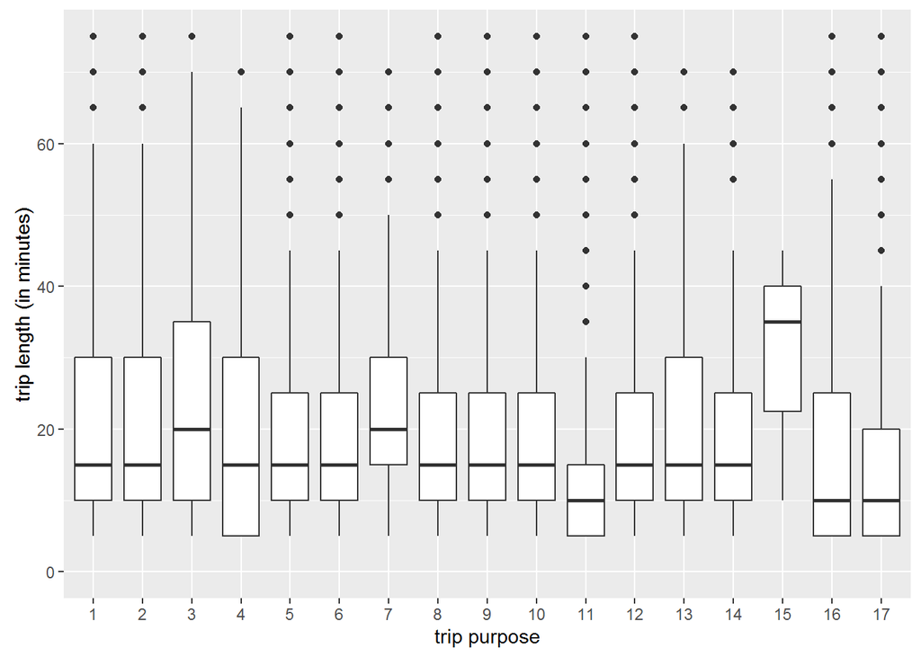

```r
# trip length by mode

# trip length by purpose
ggplot(df,aes(as.factor(d_purpose),trip_dur_reported)) + geom_boxplot() +
  # facet_grid(college~.,scales='free_y') +
  # scale_y_log10()+
  ylim(0,75) +
  ylab('trip length (in minutes)') + xlab('trip purpose')
```

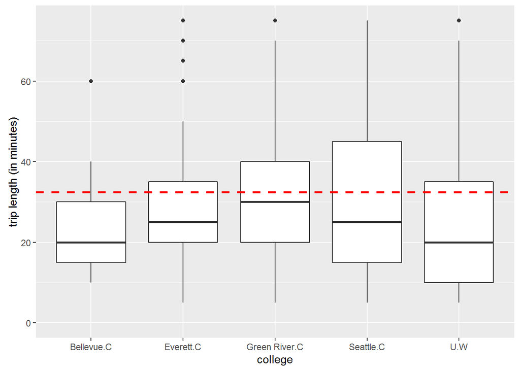

```r
# commute trip length by college
ggplot(df[df$trip_commute==1,],aes(college,trip_dur_reported)) + geom_boxplot() +
  geom_hline(aes(yintercept=mean(trip_dur_reported, na.rm=T)),
             color="red", linetype="dashed", size=1)+
  ylim(0,75) +
  ylab('trip length (in minutes)') + xlab('college')
```

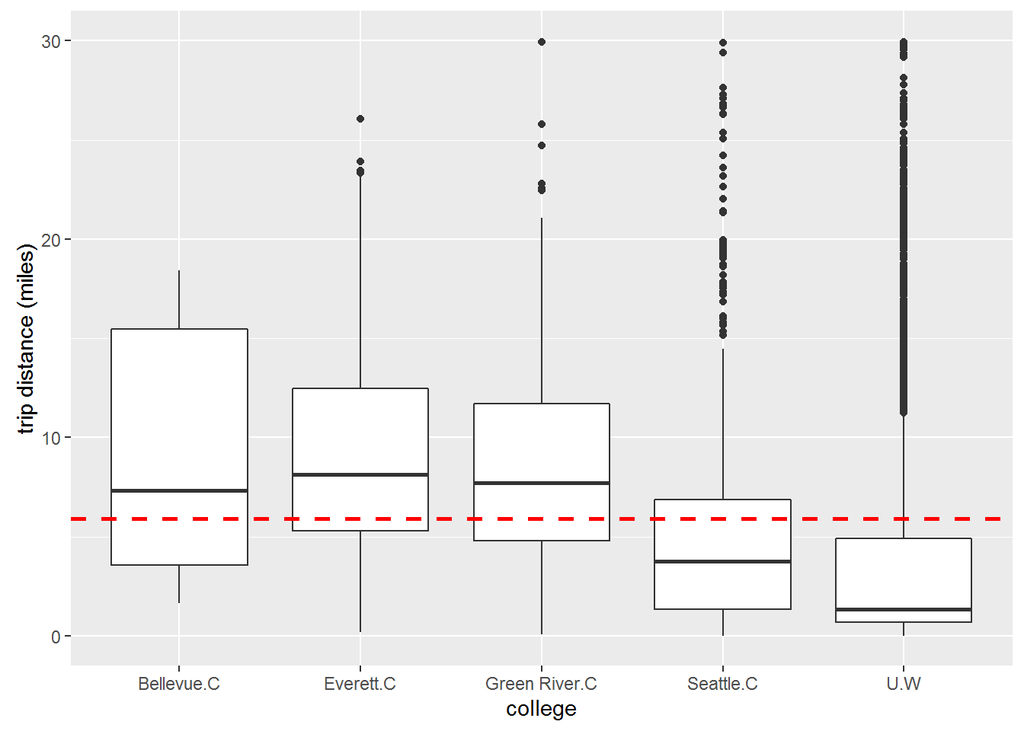

```r
ggplot(df[df$trip_commute==1,],aes(college,gdist)) + geom_boxplot() +
  geom_hline(aes(yintercept=mean(gdist, na.rm=T)),
             color="red", linetype="dashed", size=1)+
  ylim(0,30) +
  ylab('trip distance (miles)') + xlab('college')
```

```r
# distinct start and destination
# df.destinfo can be used to define commuters/non-commuters.
df.destinfo <- df.trip %>%
  select(place_start,place_end) %>%
  group_by(place_start,place_end) %>%
  summarise(cnt = n()) %>%
  # group_by(place_start) %>%
  ungroup() %>%
  arrange(desc(cnt)) %>%
  filter(place_end == 'HOME (OFF-CAMPUS)')
```

## 4. VMT per day per person

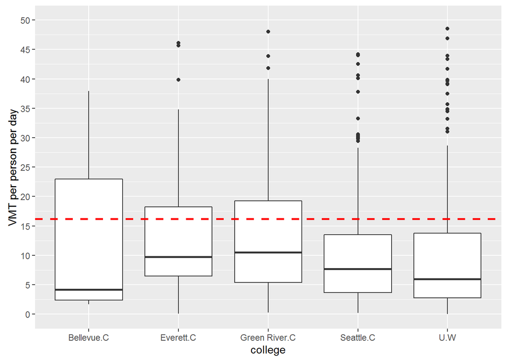

```r
#clean
df<- df%>%
  filter(mode!=16)#exclude flight trips
levels(df$h_district_name)[levels(df$h_district_name)==""] <- NA

# by college
df4.1 <- df %>%
  filter(driver==1,mode!=10) %>%
  group_by(personID,college) %>%
  summarise(vmtperday = sum(gdist)/n_distinct(traveldate))

ggplot(df4.1,aes(college,vmtperday)) + geom_boxplot() +
  geom_hline(aes(yintercept=mean(vmtperday, na.rm=T)),
             color="red", linetype="dashed", size=1)+
  scale_y_continuous(breaks = seq(0,50,5),limits = c(0,50))+
  ylab('VMT per person per day') + xlab('college')
```

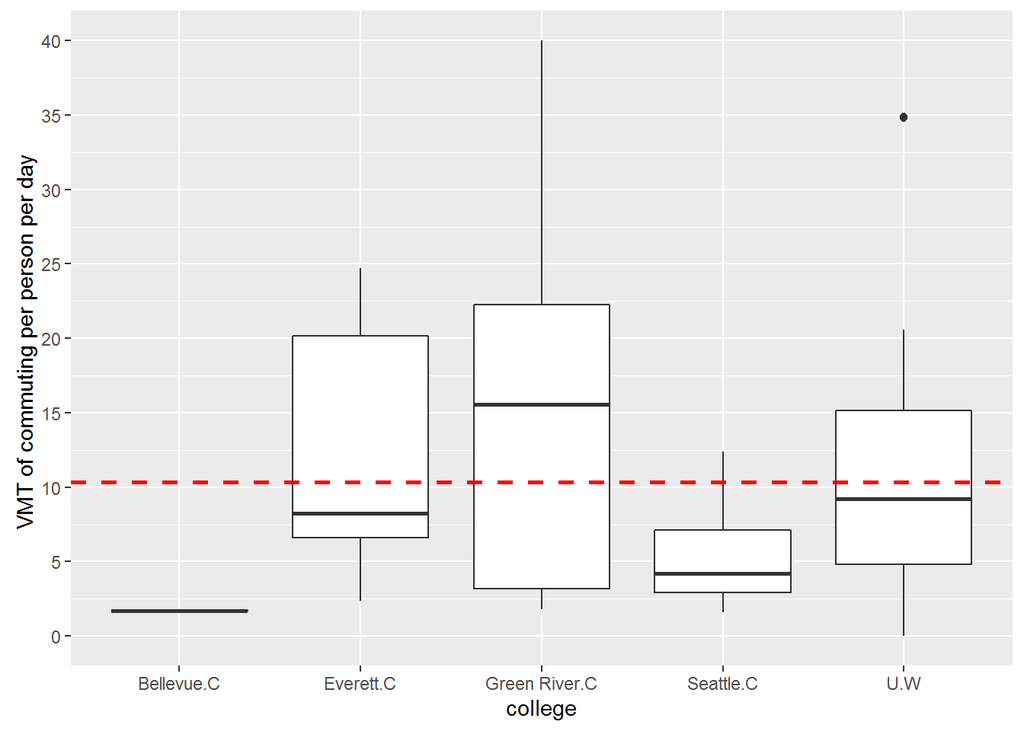

```r
# by commuter

df4.2 <- df %>%
  filter(driver==1,trip_commute==1) %>%
  group_by(personID,college) %>%
  summarise(vmtperday = sum(gdist)/n_distinct(traveldate))

ggplot(df4.2,aes(college,vmtperday)) + geom_boxplot() +
  geom_hline(aes(yintercept=mean(vmtperday, na.rm=T)),
             color="red", linetype="dashed", size=1)+
  scale_y_continuous(breaks = seq(0,40,5))+
  ylab('VMT of commuting per person per day ') + xlab('college')
```